# HW2_TS_KatieBaerveldt

### Question 3

Please complete Exercise #5 (on the cangas data set) in Chapter 6 of Hyndman text. Link to Exercise: https://otexts.com/fpp2/decomposition-exercises.html. This question is worth 30 points. Be sure to load the fpp2 package to get the cangas data set.

1. Plot the data using autoplot(), ggsubseriesplot() and ggseasonplot() to look at the effect of the changing seasonality over time. What do you think is causing it to change so much?

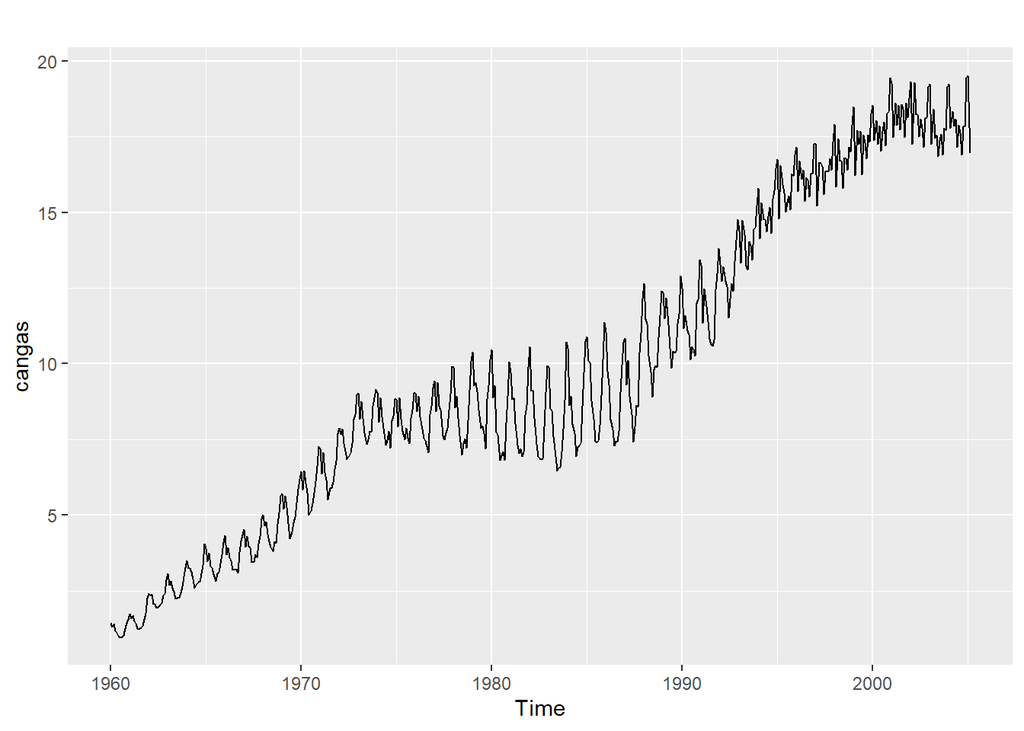

```r
?cangas

autoplot(cangas)
```

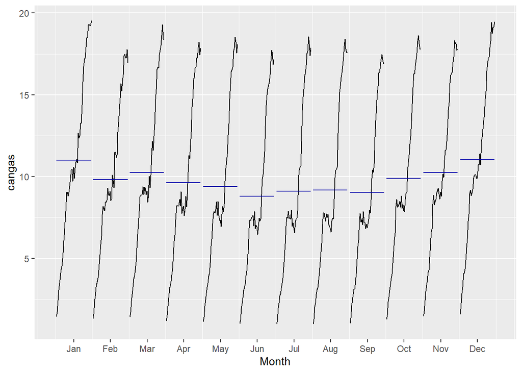

```r
ggsubseriesplot(cangas)
```

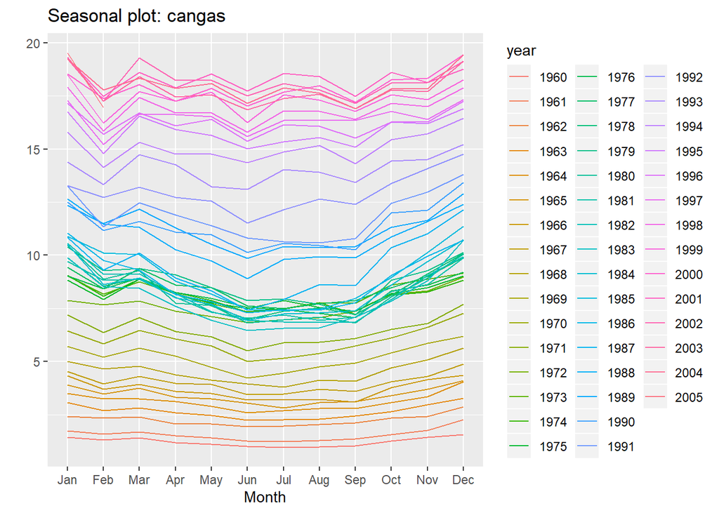

```r
ggseasonplot(cangas)
```

2. Do an STL decomposition of the data. You will need to choose s.window to allow for the changing shape of the seasonal component.

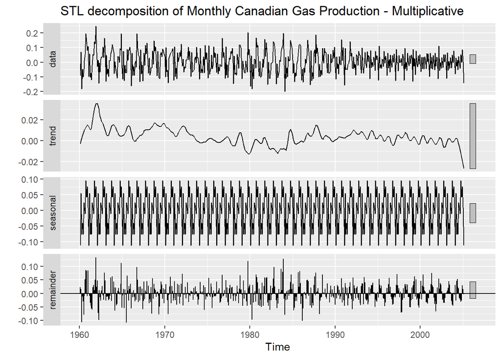

```r
# Need to take the log in order to do multiplicative STL, since there is upward trend

cangas.STL <- diff(log(cangas))

fit <- stl(cangas.STL, s.window="periodic", robust=TRUE)
autoplot(fit) +
  ggtitle("STL decomposition of Monthly Canadian Gas Production - Multiplicative")
```

The log allows me to take a multiplicative approach. I can see that there is a faintly positive trend since the relationship tapers above 0 for most of the data, but it captures the slight fall in the middle and especially near the end. This seems to be a better predictor of trend to come. I also see there is seasonality, where the beginning and end of the year show a positive value for production.

I’ll look at how this compares to the addiditive approach out of curiousity:

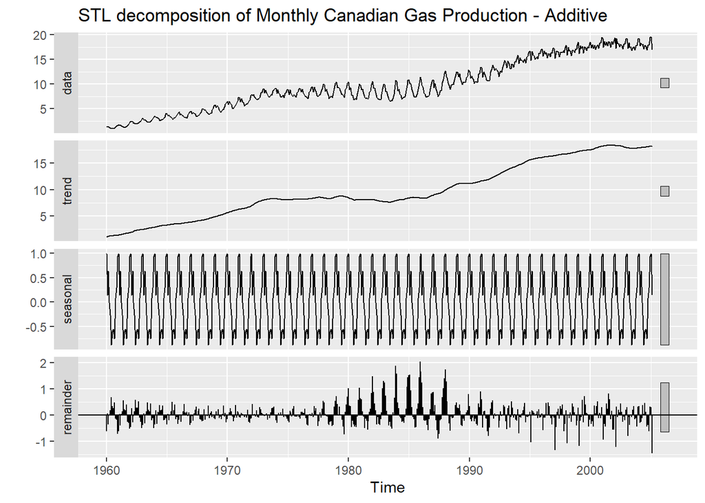

```r
fit <- stl(cangas, s.window="periodic", robust=TRUE)
autoplot(fit) +
  ggtitle("STL decomposition of Monthly Canadian Gas Production - Additive")
```

The findings from the multiplicative model can still be derived here, but don’t seem as obvious to me. I also notice that there is more remainder data in the middle of the time series.

3. Compare the results with those obtained using SEATS and X11. How are they different?

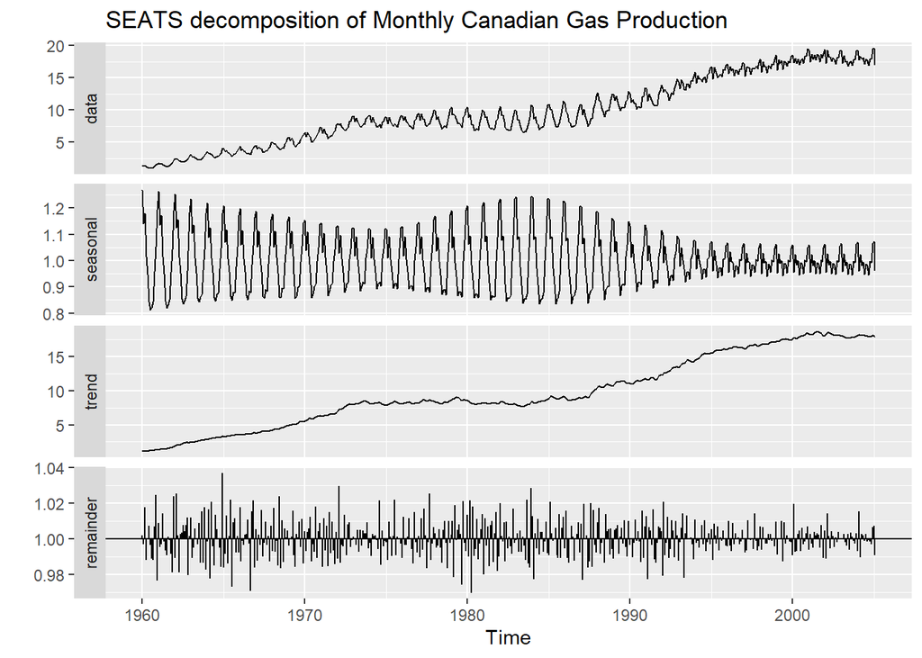

```r
# SEATS #
fit.seats.cangas <- seas(cangas)
autoplot(fit.seats.cangas) +
  ggtitle("SEATS decomposition of Monthly Canadian Gas Production")
```

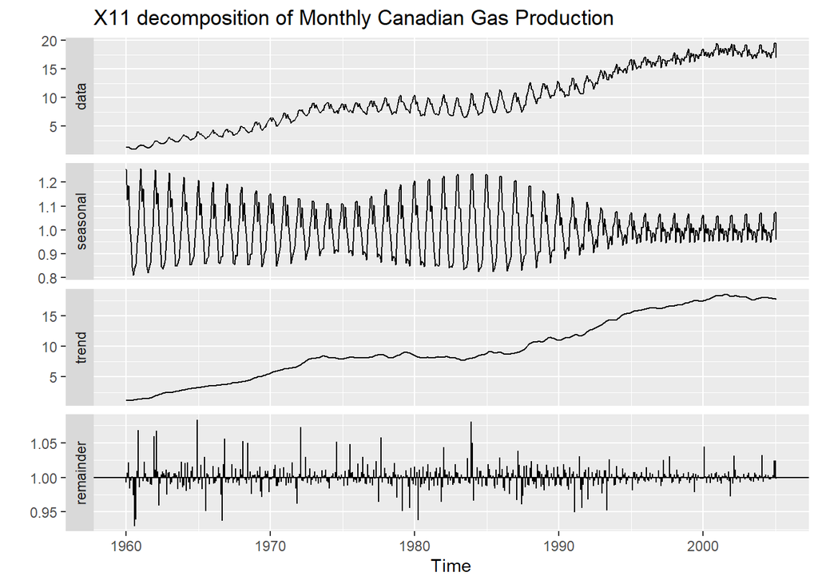

```r
# X11 #
fit.x11.cangas <- seas(cangas, x11="")
autoplot(fit.x11.cangas) +  ggtitle("X11 decomposition of Monthly Canadian Gas Production")
```

```r
#the log value, cangas.stl, produced very high remainders when I tried using that instead
```

# **Homework 2: Part B**

### Question 4

Look up the help file for the eggs data set (i.e. type ?eggs into R Studio console). The eggs data set contains the price of a dozen eggs in the United States between 1900 and 1993.

```r
?eggs
```

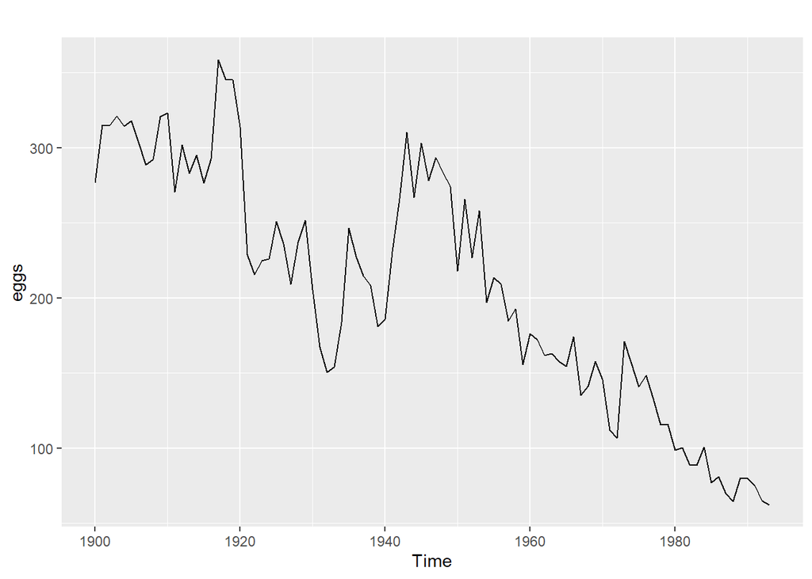

```r
autoplot(eggs)
```

There’s a noticeable downward trend in price in the data. I’m curious about the large valley and then steep rise in price in the center of the data. Since this is such a large period of time, I’m going to take a closer look.

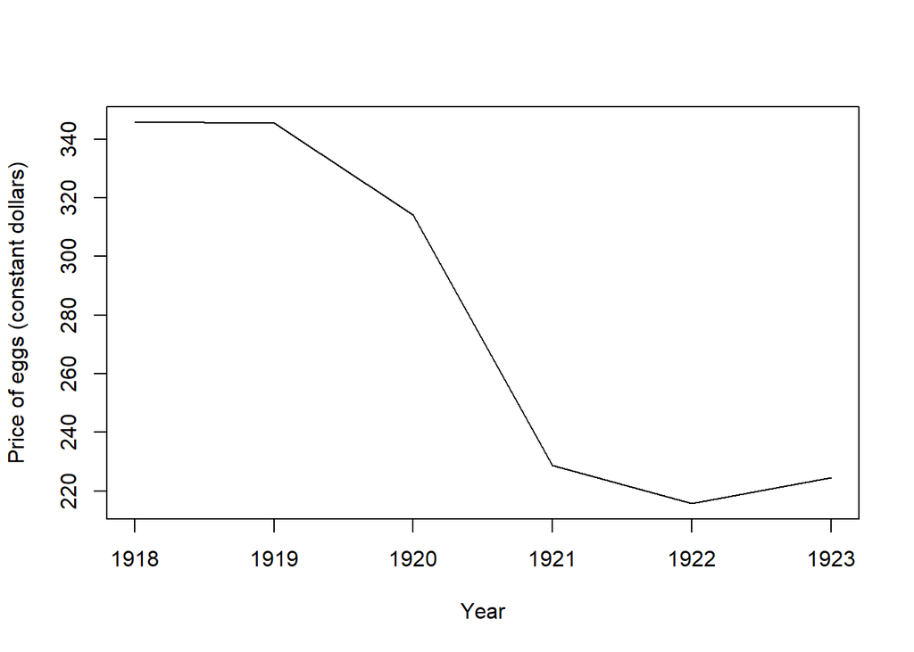

```r
eggdata1 <- window(eggs, start = 1918, end = 1923)
plot(eggdata1, ylab = "Price of eggs (constant dollars)", xlab = "Year")
```

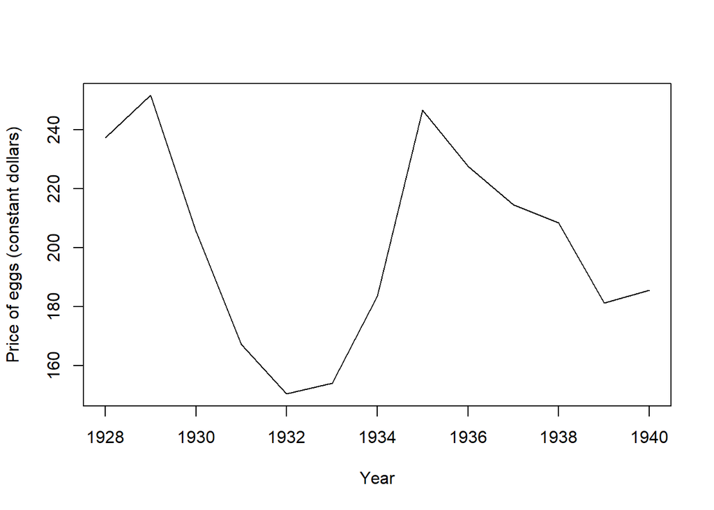

```r
eggdata2 <- window(eggs, start = 1928, end = 1940)
plot(eggdata2, ylab = "Price of eggs (constant dollars)", xlab = "Year")
```

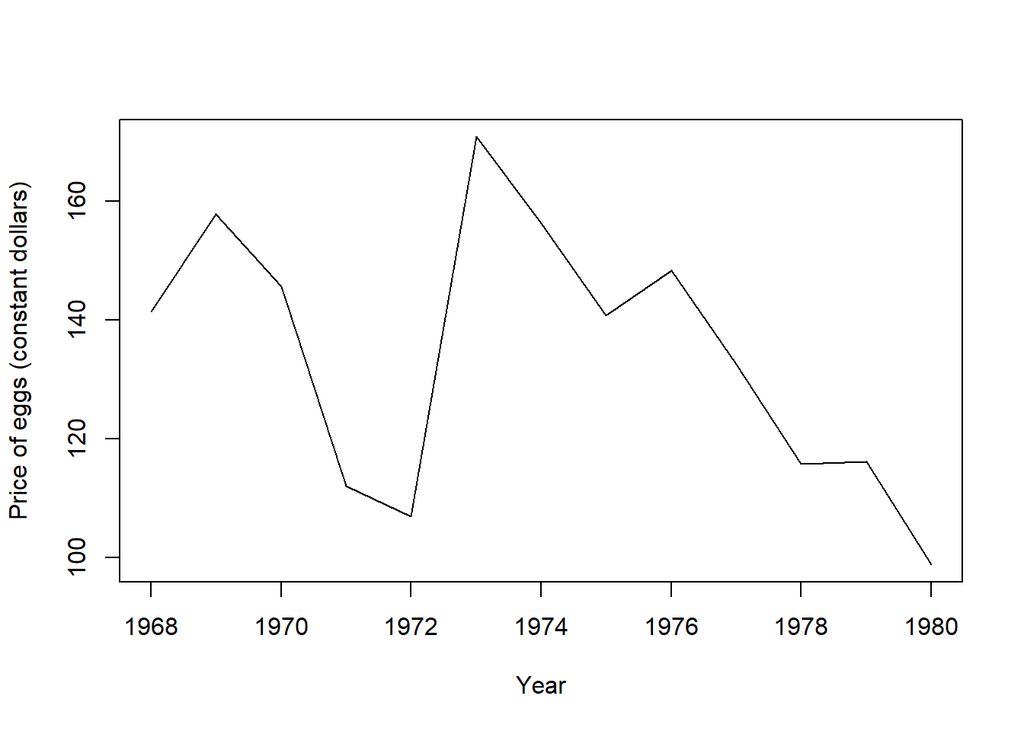

```r
eggdata3 <- window(eggs, start = 1968, end = 1980)
plot(eggdata3, ylab = "Price of eggs (constant dollars)", xlab = "Year")
```

These sharp falls and increases seem to take place over the course of only a few short years each. It’s likely that egg price is correlated with the state of the economy. Because of this suspicion, I would describe this as cyclical.

Forecast 1) Mean

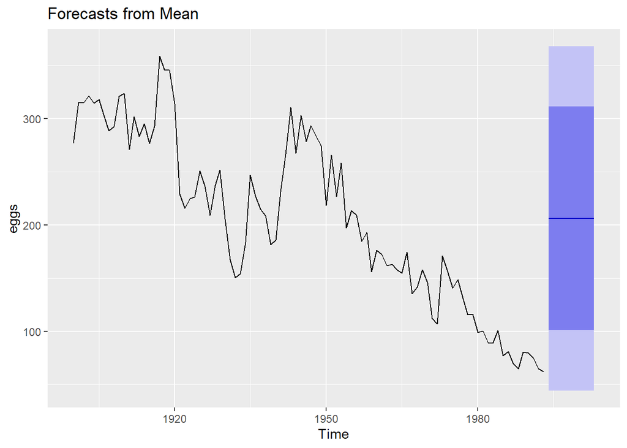

```r
mean <- meanf(eggs, h=10)
autoplot(mean)
```

```r
summary(mean)
```

```
##
## Forecast method: Mean
##
## Model Information:
## $mu
## [1] 206.1463
##
## $mu.se
## [1] 8.363469
##
## $sd
## [1] 81.08685
##
## $bootstrap
## [1] FALSE
##
## $call
## meanf(y = eggs, h = 10)
##
## attr(,"class")
## [1] "meanf"
##
## Error measures:
##                         ME     RMSE      MAE       MPE     MAPE     MASE
## Training set -1.363685e-14 80.65438 69.11282 -23.53921 47.04173 3.409231
##                  ACF1
## Training set 0.923673
##
## Forecasts:
##      Point Forecast    Lo 80   Hi 80    Lo 95    Hi 95
## 1994       206.1463 100.9306 311.362 44.26964 368.0229
## 1995       206.1463 100.9306 311.362 44.26964 368.0229
## 1996       206.1463 100.9306 311.362 44.26964 368.0229
## 1997       206.1463 100.9306 311.362 44.26964 368.0229
## 1998       206.1463 100.9306 311.362 44.26964 368.0229
## 1999       206.1463 100.9306 311.362 44.26964 368.0229
## 2000       206.1463 100.9306 311.362 44.26964 368.0229
## 2001       206.1463 100.9306 311.362 44.26964 368.0229
## 2002       206.1463 100.9306 311.362 44.26964 368.0229
## 2003       206.1463 100.9306 311.362 44.26964 368.0229
```

Forecast 2) Naive

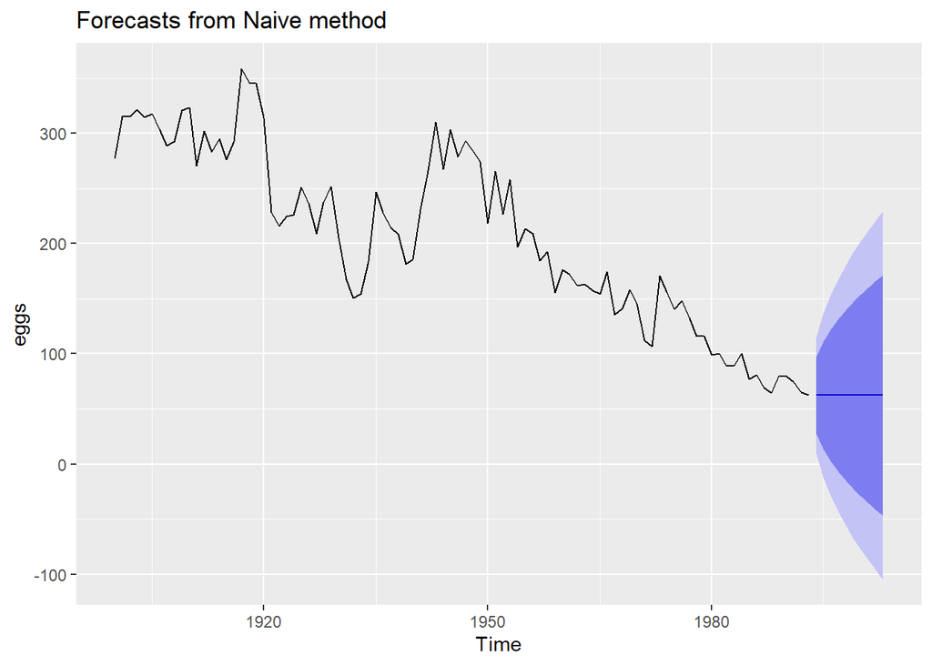

```r
naive <- naive(eggs, h=10)
autoplot(naive)
```

```r
summary(naive)
```

```
##
## Forecast method: Naive method
##
## Model Information:
## Call: naive(y = eggs, h = 10)
##
## Residual sd: 27.0184
##
## Error measures:
##                     ME     RMSE      MAE       MPE     MAPE MASE      ACF1
## Training set -2.306667 26.97157 20.27226 -2.497352 10.42787    1 -0.146613
##
## Forecasts:
##      Point Forecast      Lo 80     Hi 80       Lo 95    Hi 95
## 1994          62.27  27.704544  96.83546    9.406697 115.1333
## 1995          62.27  13.387064 111.15294  -12.490000 137.0300
## 1996          62.27   2.400874 122.13913  -29.291926 153.8319
## 1997          62.27  -6.860911 131.40091  -43.456605 167.9966
## 1998          62.27 -15.020709 139.56071  -55.935938 180.4759
## 1999          62.27 -22.397729 146.93773  -67.218118 191.7581
## 2000          62.27 -29.181600 153.72160  -77.593152 202.1332
## 2001          62.27 -35.495873 160.03587  -87.249999 211.7900
## 2002          62.27 -41.426367 165.96637  -96.319908 220.8599
## 2003          62.27 -47.035568 171.57557 -104.898441 229.4384
```

Forecast 3) Weighted Avg SES

```r
# Borrowed from class example in order to test alpha values

fit1 <- ses(eggs, alpha = 0.5, initial = "simple", h = 10)
fit2 <- ses(eggs, alpha = 0.9, initial = "simple", h = 10)
fit3 <- ses(eggs, h = 10)

summary(fit1)
```

```
##
## Forecast method: Simple exponential smoothing
##
## Model Information:
## Simple exponential smoothing
##
## Call:
##  ses(y = eggs, h = 10, initial = "simple", alpha = 0.5)
##
##   Smoothing parameters:
##     alpha = 0.5
##
##   Initial states:
##     l = 276.79
##
##   sigma:  28.1053
## Error measures:
##                     ME     RMSE      MAE       MPE     MAPE     MASE
## Training set -4.476275 28.10529 20.78601 -4.503297 11.16961 1.025343
##                   ACF1
## Training set 0.3216375
##
## Forecasts:
##      Point Forecast     Lo 80    Hi 80      Lo 95    Hi 95
## 1994       66.40509 30.386713 102.4235  11.319738 121.4904
## 1995       66.40509 26.135321 106.6749   4.817795 127.9924
## 1996       66.40509 22.291769 110.5184  -1.060411 133.8706
## 1997       66.40509 18.757257 114.0529  -6.465980 139.2762
## 1998       66.40509 15.467415 117.3428 -11.497360 144.3075
## 1999       66.40509 12.377527 120.4326 -16.222936 149.0331
## 2000       66.40509  9.455038 123.3551 -20.692496 153.5027
## 2001       66.40509  6.675372 126.1348 -24.943629 157.7538
## 2002       66.40509  4.019434 128.7907 -29.005535 161.8157
## 2003       66.40509  1.472041 131.3381 -32.901437 165.7116
```

```r
summary(fit2)
```

```
##
## Forecast method: Simple exponential smoothing
##
## Model Information:
## Simple exponential smoothing
##
## Call:
##  ses(y = eggs, h = 10, initial = "simple", alpha = 0.9)
##
##   Smoothing parameters:
##     alpha = 0.9
##
##   Initial states:
##     l = 276.79
##
##   sigma:  26.5934
## Error measures:
##                     ME     RMSE      MAE       MPE     MAPE      MASE
## Training set -2.531404 26.59341 19.54394 -2.714484 10.10731 0.9640732
##                     ACF1
## Training set -0.04795883
##
## Forecasts:
##      Point Forecast       Lo 80     Hi 80      Lo 95    Hi 95
## 1994       62.63321  28.5523762  96.71403  10.511075 114.7553
## 1995       62.63321  16.7821392 108.48427  -7.489949 132.7564
## 1996       62.63321   7.4685644 117.79785 -21.733832 147.0002
## 1997       62.63321  -0.4853733 125.75178 -33.898330 159.1647
## 1998       62.63321  -7.5435167 132.80993 -44.692829 169.9592
## 1999       62.63321 -13.9539324 139.22034 -54.496714 179.7631
## 2000       62.63321 -19.8677462 145.13416 -63.541112 188.8075
## 2001       62.63321 -25.3851130 150.65152 -71.979196 197.2456
## 2002       62.63321 -30.5764600 155.84287 -79.918676 205.1851
## 2003       62.63321 -35.4935446 160.75995 -87.438708 212.7051
```

```r
summary(fit3)
```

```
##
## Forecast method: Simple exponential smoothing
##
## Model Information:
## Simple exponential smoothing
##
## Call:
##  ses(y = eggs, h = 10)
##
##   Smoothing parameters:
##     alpha = 0.8525
##
##   Initial states:
##     l = 282.4981
##
##   sigma:  26.8511
##
##      AIC     AICc      BIC
## 1049.626 1049.893 1057.256
##
## Error measures:
##                     ME     RMSE      MAE       MPE     MAPE      MASE
## Training set -2.740622 26.56395 19.38206 -2.872958 10.05648 0.9560879
##                      ACF1
## Training set -0.005983602
##
## Forecasts:
##      Point Forecast      Lo 80     Hi 80      Lo 95    Hi 95
## 1994       62.88346  28.472350  97.29457  10.256209 115.5107
## 1995       62.88346  17.665600 108.10132  -6.271289 132.0382
## 1996       62.88346   8.983689 116.78323 -19.549125 145.3160
## 1997       62.88346   1.518033 124.24888 -30.966861 156.7338
## 1998       62.88346  -5.133053 130.89997 -41.138819 166.9057
## 1999       62.88346 -11.189318 136.95624 -50.401077 176.1680
## 2000       62.88346 -16.786527 142.55344 -58.961269 184.7282
## 2001       62.88346 -22.015522 147.78244 -66.958328 192.7252
## 2002       62.88346 -26.940632 152.70755 -74.490633 200.2576
## 2003       62.88346 -31.609386 157.37630 -81.630876 207.3978
```

I’m going to go ahead and move forward with an alpha of 0.8525 - it seems that more recent data is useful here due to the large amount of time series data at hand.

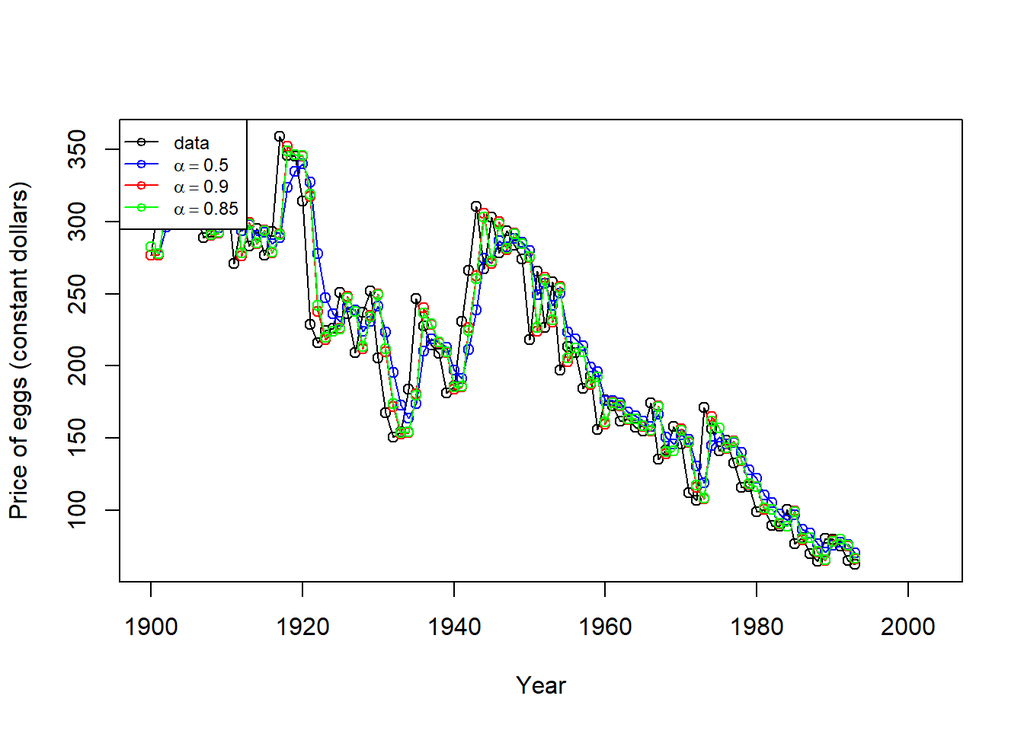

```r
plot(fit1, PI=FALSE, ylab="Price of eggs (constant dollars)",
     xlab="Year", main="", fcol="white", type="o")
lines(fitted(fit1), col="blue", type="o")
lines(fitted(fit2), col="red", type="o")
lines(fitted(fit3), col="green", type="o")

legend("topleft",lty=1, col=c(1,"blue","red","green"), cex = 0.75,
       c("data", expression(alpha == 0.5), expression(alpha == 0.9),
         expression(alpha == 0.85)),pch=1)
```

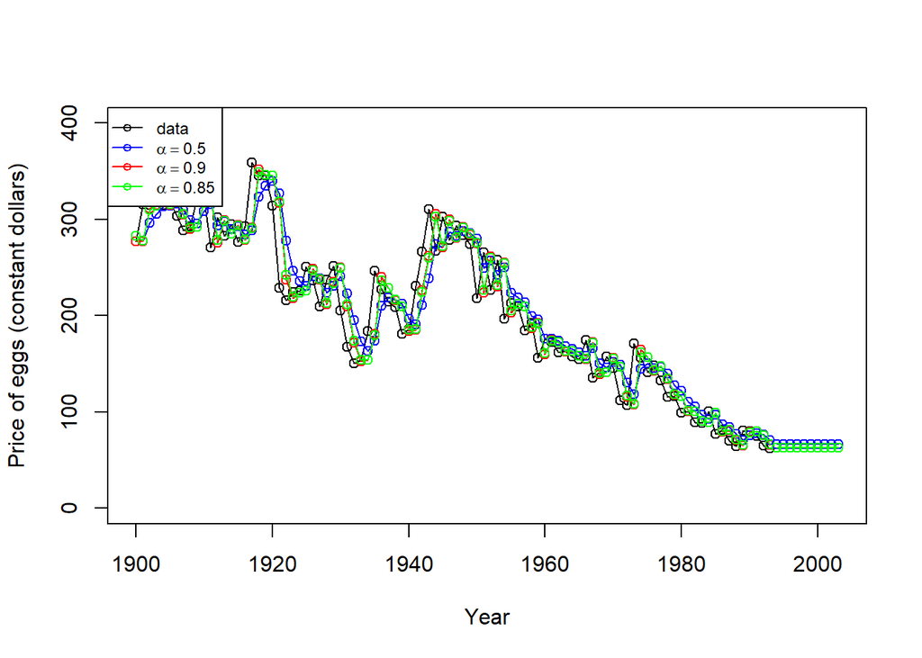

```r
plot(fit1, PI=FALSE, ylim = c(0, 400), ylab="Price of eggs (constant dollars)",
xlab="Year", main="", fcol="white", type="o")
test.eggs <- window(eggs, start = 1993)
lines(test.eggs, col = "black", type = "o")
lines(fitted(fit1), col="blue", type="o")
lines(fitted(fit2), col="red", type="o")
lines(fitted(fit3), col="green", type="o")
lines(fit1$mean, col="blue", type="o")
lines(fit2$mean, col="red", type="o")
lines(fit3$mean, col="green", type="o")
legend("topleft",lty=1, cex =0.75, col=c(1,"blue","red","green"),
c("data", expression(alpha == 0.5), expression(alpha == 0.9),
expression(alpha == 0.85)),pch=1)
```

Forecast 4) Holt Method - Additive

```r
fit.holt <- holt(eggs, alpha=0.85, beta=0.15, initial="simple", h=10)
summary(fit.holt)
```

```
##
## Forecast method: Holt's method
##
## Model Information:
## Holt's method
##
## Call:
##  holt(y = eggs, h = 10, initial = "simple", alpha = 0.85, beta = 0.15)
##
##   Smoothing parameters:
##     alpha = 0.85
##     beta  = 0.15
##
##   Initial states:
##     l = 276.79
##     b = 38.63
##
##   sigma:  29.0496
## Error measures:
##                     ME     RMSE      MAE       MPE     MAPE    MASE
## Training set -3.500017 29.04963 22.26888 -1.813447 10.96457 1.09849
##                    ACF1
## Training set 0.03931691
##
## Forecasts:
##      Point Forecast       Lo 80     Hi 80       Lo 95    Hi 95
## 1994       59.03489   21.806299  96.26349    2.098672 115.9711
## 1995       55.71719    3.068006 108.36637  -24.802787 136.2372
## 1996       52.39948  -15.459777 120.25874  -51.382299 156.1813
## 1997       49.08178  -34.267878 132.43144  -78.390522 176.5541
## 1998       45.76407  -53.539316 145.06747 -106.107356 197.6355
## 1999       42.44637  -73.351911 158.24465 -134.651819 219.5446
## 2000       39.12867  -93.738823 171.99615 -164.074623 242.3320
## 2001       35.81096 -114.711843 186.33377 -194.393802 266.0157
## 2002       32.49326 -136.271804 201.25832 -225.610631 290.5971
## 2003       29.17555 -158.413711 216.76482 -257.717469 316.0686
```

```r
eggs[1]
```

```
## [1] 276.79
```

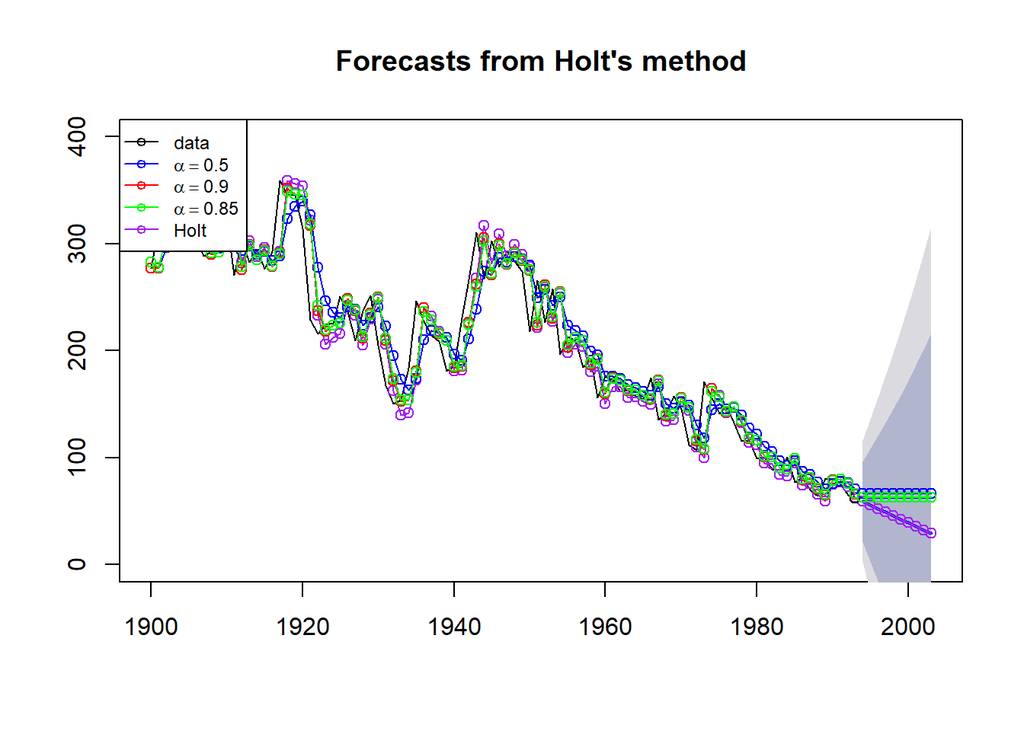

```r
plot(fit.holt, PI=TRUE, ylim = c(0, 400))
lines(fitted(fit.holt), type = "o", col="purple")
lines(fit.holt$mean, col="purple", type="o")
lines(test.eggs, col = "black", type = "o")
lines(fitted(fit1), col="blue", type="o")
lines(fitted(fit2), col="red", type="o")
lines(fitted(fit3), col="green", type="o")
lines(fit1$mean, col="blue", type="o")
lines(fit2$mean, col="red", type="o")
lines(fit3$mean, col="green", type="o")
legend("topleft",lty=1, cex = 0.75, col=c(1,"blue","red","green", "purple"),
       c("data", expression(alpha == 0.5), expression(alpha == 0.9),
         expression(alpha == 0.85),"Holt"),pch=1)
```

Forecast 5) Holt Method - Multiplicative (Exponential)

```r
fit.holt2 <- holt(eggs,alpha=0.85,beta=0.15,initial="simple",exponential=TRUE,h=10)
summary(fit.holt2)
```

```
##
## Forecast method: Holt's method with exponential trend
##
## Model Information:
## Holt's method with exponential trend
##
## Call:
##  holt(y = eggs, h = 10, initial = "simple", exponential = TRUE,
##
##  Call:
##      alpha = 0.85, beta = 0.15)
##
##   Smoothing parameters:
##     alpha = 0.85
##     beta  = 0.15
##
##   Initial states:
##     l = 276.79
##     b = 1.1396
##
##   sigma:  0.1462
## Error measures:
##                     ME     RMSE      MAE       MPE     MAPE     MASE
## Training set -6.079868 29.55065 22.66626 -3.247816 11.17047 1.118092
##                   ACF1
## Training set 0.0404052
##
## Forecasts:
##      Point Forecast    Lo 80     Hi 80     Lo 95     Hi 95
## 1994       60.33892 49.30434  71.91292 42.986240  77.36013
## 1995       58.20465 43.56912  74.69109 37.190215  83.24615
## 1996       56.14587 38.37835  77.46179 31.471237  90.30459
## 1997       54.15991 34.29736  80.60874 26.568445  99.46196
## 1998       52.24420 30.38125  84.49528 22.724547 108.18079
## 1999       50.39625 26.61076  85.99483 18.873387 116.88362
## 2000       48.61366 23.28139  89.98051 15.944796 124.12332
## 2001       46.89413 20.24994  94.30379 13.251033 136.17666
## 2002       45.23542 17.77339  98.26167 11.016465 148.10719
## 2003       43.63538 15.45759 102.95492  9.154873 163.92399
```

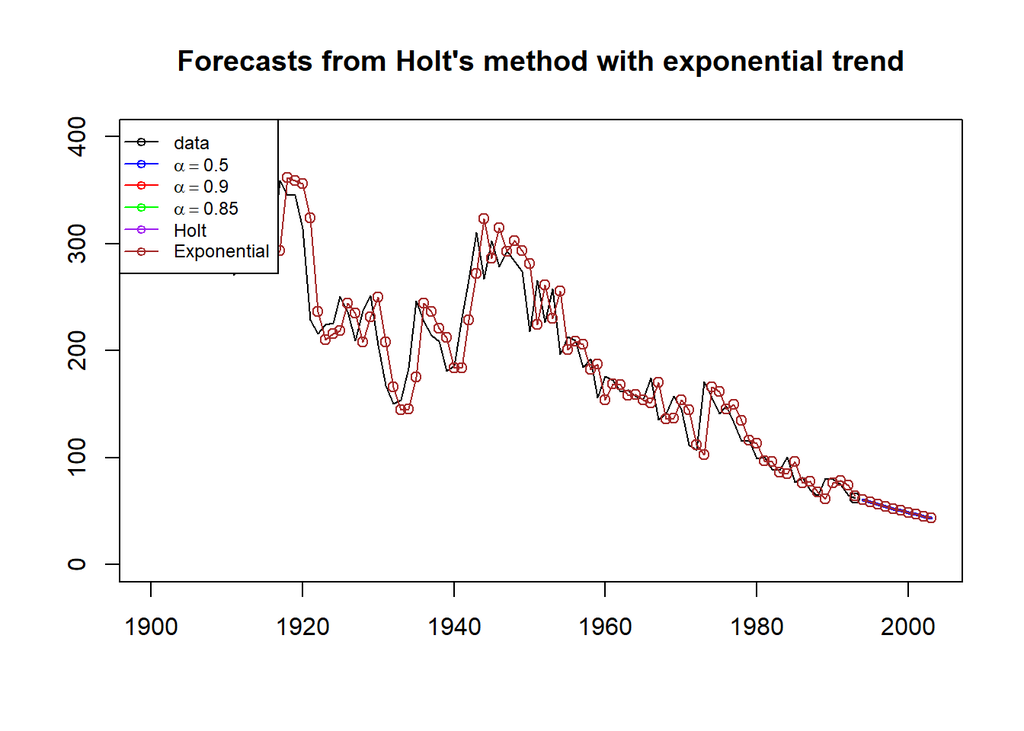

```r
plot(fit.holt2, PI=FALSE, ylim = c(0, 400))
lines(test.eggs, col = "black", type = "o")
lines(fitted(fit.holt2), col="brown", type = "o")
lines(fit.holt2$mean, col="brown", type="o")
legend("topleft", cex =0.75, lty=1, col=c(1,"blue","red","green", "purple", "brown"),
       c("data", expression(alpha == 0.5), expression(alpha == 0.9),
         expression(alpha == 0.85),"Holt","Exponential"),pch=1)
```

Forecast 6) Holt Method - Damped Multiplicative

I’m choosing to employ dampening on the multiplicative model because there is downward trend in the overall data

```r
fit.holt3 <- holt(eggs,alpha=0.85,beta=0.15,initial="simple",exponential=TRUE,
              damped=TRUE, phi=NULL, h=10)
summary(fit.holt3)
```

```
##
## Forecast method: Damped Holt's method with exponential trend
##
## Model Information:
## Damped Holt's method with exponential trend
##
## Call:
##  holt(y = eggs, h = 10, damped = TRUE, initial = "simple", exponential = TRUE,
##
##  Call:
##      alpha = 0.85, beta = 0.15, phi = NULL)
##
##   Smoothing parameters:
##     alpha = 0.85
##     beta  = 0.15
##     phi   = 0.8
##
##   Initial states:
##     l = 304.7873
##     b = 1
##
##   sigma:  0.1445
##
##      AIC     AICc      BIC
## 1053.454 1053.904 1063.628
##
## Error measures:
##                     ME     RMSE     MAE       MPE     MAPE     MASE
## Training set -2.867987 27.56522 20.7852 -2.566604 10.59506 1.025302
##                     ACF1
## Training set -0.07129492
##
## Forecasts:
##      Point Forecast    Lo 80     Hi 80    Lo 95     Hi 95
## 1994       61.46384 49.91127  72.99247 44.37368  79.58769
## 1995       60.23636 45.28908  77.45631 38.13637  87.65996
## 1996       59.27205 41.35060  80.91908 33.88038  95.00759
## 1997       58.51172 37.85736  85.12827 30.74959 102.80415
## 1998       57.91049 34.96961  88.94619 27.72563 112.51991
## 1999       57.43396 32.84007  92.86534 24.39343 120.52805
## 2000       57.05555 30.34315  97.29399 22.07992 130.03108
## 2001       56.75463 28.75798 100.75585 19.98945 138.26036
## 2002       56.51503 26.57944 104.70247 18.18885 149.23522
## 2003       56.32408 24.98146 109.31749 16.68759 159.81048
```

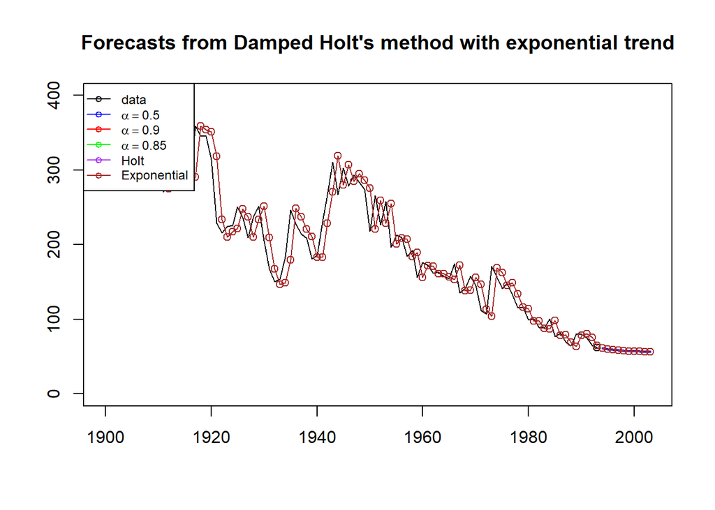

```r
plot(fit.holt3, PI=FALSE, ylim = c(0, 400))
lines(test.eggs, col = "black", type = "o")
lines(fitted(fit.holt3), col="brown", type = "o")
lines(fit.holt3$mean, col="brown", type="o")
legend("topleft", cex =0.75, lty=1, col=c(1,"blue","red","green", "purple", "brown"),
       c("data", expression(alpha == 0.5), expression(alpha == 0.9),
         expression(alpha == 0.85),"Holt","Exponential"),pch=1)
```

### Question 5

Look up the help file for the ukcars data set (i.e. type ?ukcars into R Studio console). The data set contains quarterly UK passenger vehicle production from 1977:1 (first quarter of 1977) to 2005:1 (first quarter of 2005).

```r
?ukcars
```

1. Plot and comment on the features of the time series. Decompose the time series using STL and obtain the seasonally adjusted data.

Standard TS plot:

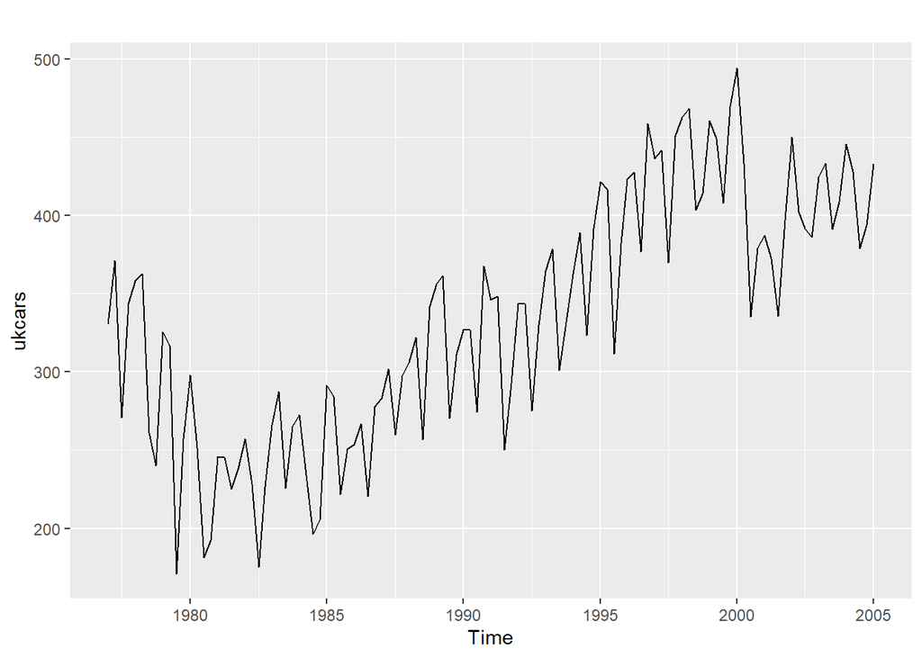

```r
autoplot(ukcars)
```

From the data alone there appears to be a slight upward trend, however I am curious if this is a snapshot of a larger picture since there is a decrease in car production in the beginning of this time grame and again toward the end. This may be cyclical. There also appears to be some seasonality due to the constant ebbing and flowing of the data; for example, peaks seem to occur at the beginning of each year which suggests that there is a rise in production around the holidays.

STL Decomposition:

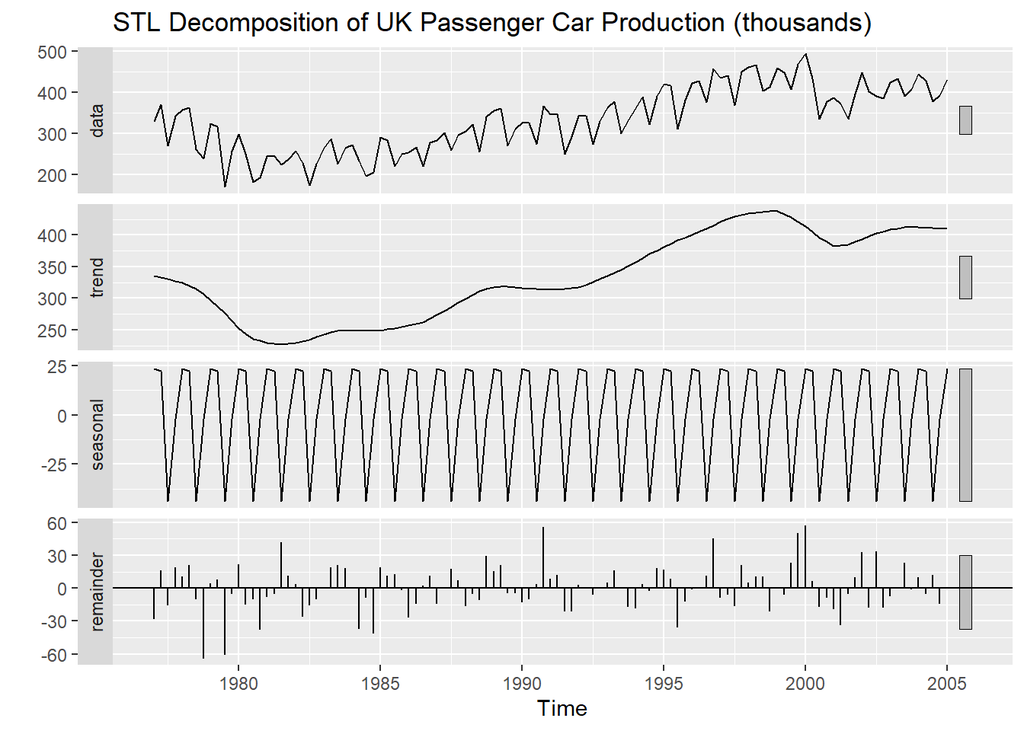

```r
ukcars.stl <- stl(ukcars, t.window = 13, s.window="periodic", robust=TRUE)
autoplot(ukcars.stl) +
  ggtitle("STL Decomposition of UK Passenger Car Production (thousands)")
```

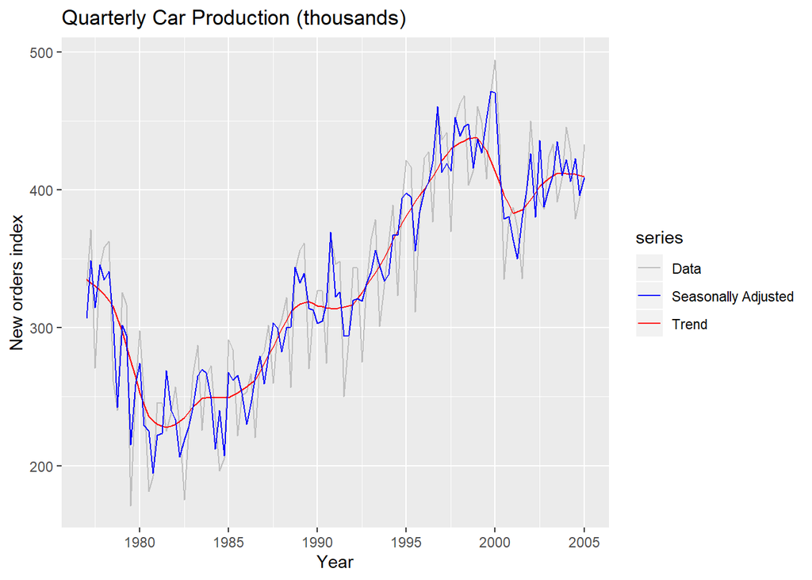

```r
autoplot(ukcars, series="Data") +
  autolayer(trendcycle(ukcars.stl), series="Trend") +
  autolayer(seasadj(ukcars.stl), series="Seasonally Adjusted") +
  xlab("Year") + ylab("New orders index") +
  ggtitle("Quarterly Car Production (thousands)") +
  scale_colour_manual(values=c("gray","blue","red"),
                     breaks=c("Data","Seasonally Adjusted","Trend"))
```

b. Forecast the next two years of the series using Holts linear trend method applied to the seasonally adjusted data. What are the parameters of the method? What do they tell you about how quickly the slope and level are changing over time?

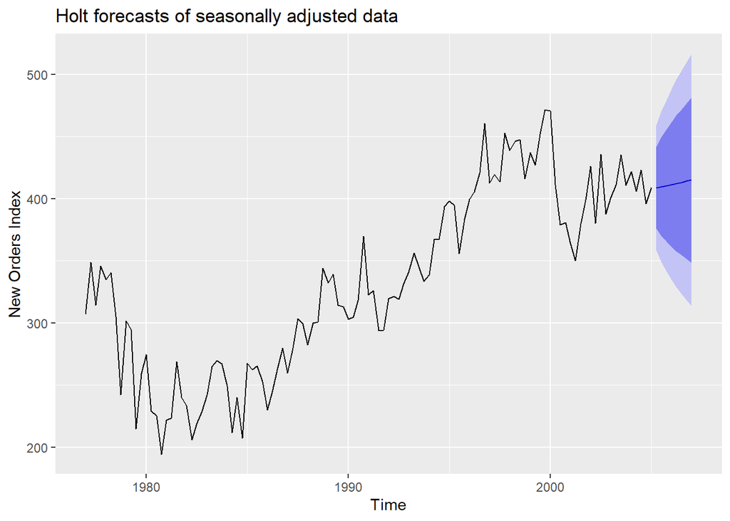

```r
ukcars.stl %>% seasadj() %>% holt(,h = 8) %>% autoplot()+ ylab("New Orders Index") + ggtitle("Holt forecasts of seasonally adjusted data")
```

```r
fit_uk_stl <- ukcars.stl %>% seasadj() %>% holt(,h = 8)

summary(fit_uk_stl)
```

```
##
## Forecast method: Holt's method
##
## Model Information:
## Holt's method
##
## Call:
##  holt(y = ., h = 8)
##
##   Smoothing parameters:
##     alpha = 0.6601
##     beta  = 1e-04
##
##   Initial states:
##     l = 323.2488
##     b = 0.9034
##
##   sigma:  25.7421
##
##      AIC     AICc      BIC
## 1274.199 1274.760 1287.836
##
## Error measures:
##                      ME     RMSE      MAE        MPE     MAPE      MASE
## Training set -0.2262297 25.28237 19.91345 -0.5932861 6.428203 0.6489695
##                     ACF1
## Training set -0.01471865
##
## Forecasts:
##         Point Forecast    Lo 80    Hi 80    Lo 95    Hi 95
## 2005 Q2       408.6652 375.6754 441.6550 358.2117 459.1188
## 2005 Q3       409.5661 370.0358 449.0963 349.1098 470.0224
## 2005 Q4       410.4669 365.3328 455.6011 341.4402 479.4937
## 2006 Q1       411.3678 361.2510 461.4846 334.7208 488.0149
## 2006 Q2       412.2687 357.6204 466.9170 328.6913 495.8461
## 2006 Q3       413.1696 354.3365 472.0026 323.1922 503.1469
## 2006 Q4       414.0704 351.3301 476.8108 318.1173 510.0235
## 2007 Q1       414.9713 348.5520 481.3906 313.3917 516.5509
```

3. Reseasonalize the forecasts using the following code where decomp is the output from stl() and fit is the output from holt():  
   lastyear <- rep(decomp$time.series[110:113,"seasonal"],2) fc <- fit$mean + lastyear Do the re-seasonalized forecasts look reasonable? Why or why not?

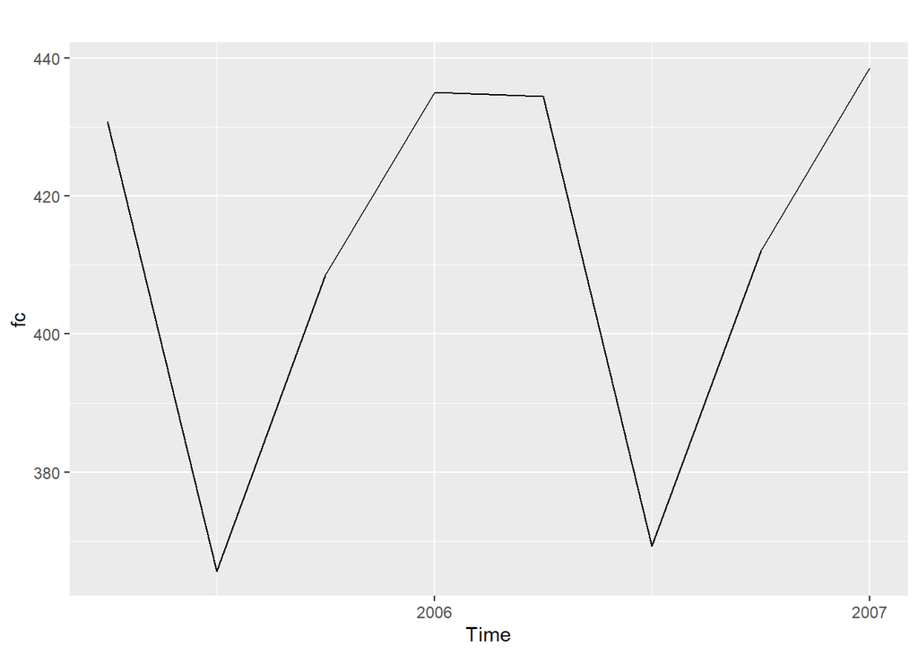

```r
lastyear <- rep(ukcars.stl$time.series[110:113,"seasonal"],2)
fc <- fit_uk_stl$mean + lastyear

autoplot(fc)
```

No, the resasonalized forecast doesn’t appear reasonable or realistic. Taking the mean and applying it to the data is giving a gross oversimplification of the trend line.

*d. Apply an X11 and a SEATS model using a two-year horizon. SKIPPED PER DISCUSSION NOTE.*

5. Use ets() to choose a seasonal model for the data. How would you explain the results? Compare the RMSE of the two models. Which gives the better in-sample fit?

Additive ETS:

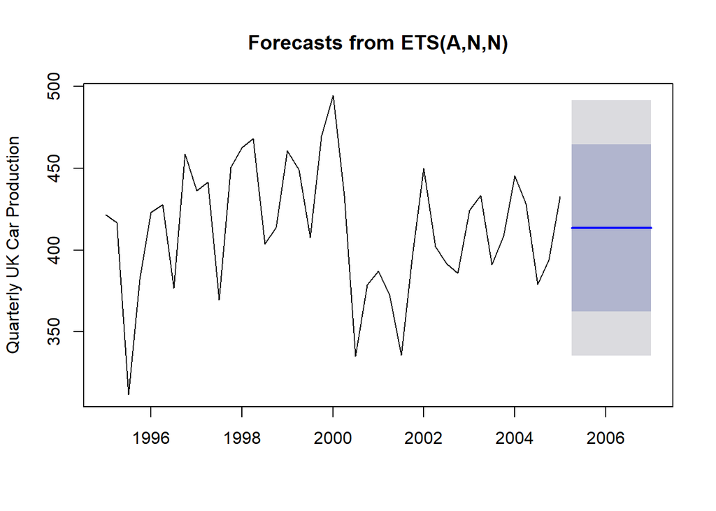

```r
cardata <- window(ukcars, start = 1995)
fit_add <- ets(cardata, model = "ANN")
plot(forecast(fit_add, h=8), ylab="Quarterly UK Car Production")
```

```r
summary(fit_add)
```

```
## ETS(A,N,N)
##
## Call:
##  ets(y = cardata, model = "ANN")
##
##   Smoothing parameters:
##     alpha = 1e-04
##
##   Initial states:
##     l = 413.4545
##
##   sigma:  39.7675
##
##      AIC     AICc      BIC
## 458.2162 458.8648 463.3569
##
## Training set error measures:
##                        ME     RMSE      MAE        MPE     MAPE     MASE
## Training set 0.0004638418 38.78547 31.46319 -0.9401565 7.852134 1.052446
##                   ACF1
## Training set 0.2880557
```

```r
ls(fit_add)
```

```
##  [1] "aic"        "aicc"       "amse"       "bic"        "call"
##  [6] "components" "fit"        "fitted"     "initstate"  "loglik"
## [11] "m"          "method"     "mse"        "par"        "residuals"
## [16] "series"     "sigma2"     "states"     "x"
```

```r
fit_add$par
```

```
##        alpha            l
## 1.000179e-04 4.134545e+02
```

I chose a more recent window to cover the last decade of the data since this would show a better representation of the forecast.

Multiplicative ETS:

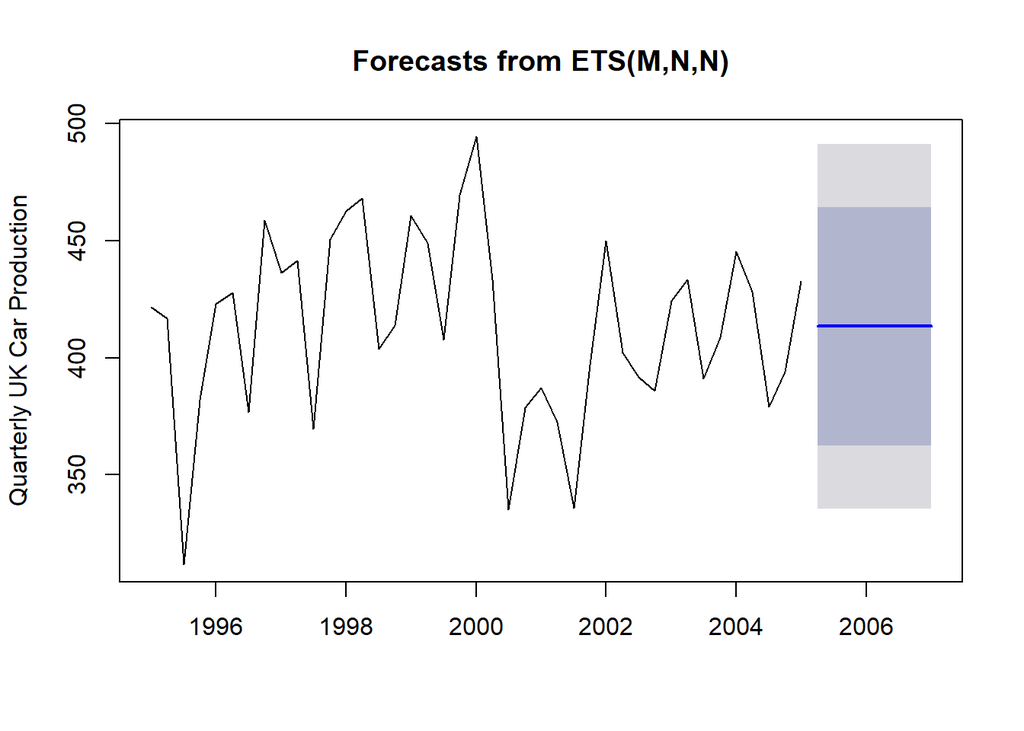

```r
fit_mult <- ets(cardata, model = "MNN")
plot(forecast(fit_mult, h=8), ylab="Quarterly UK Car Production")
```

```r
summary(fit_mult)
```

```
## ETS(M,N,N)
##
## Call:
##  ets(y = cardata, model = "MNN")
##
##   Smoothing parameters:
##     alpha = 1e-04
##
##   Initial states:
##     l = 413.3821
##
##   sigma:  0.0962
##
##      AIC     AICc      BIC
## 458.2156 458.8642 463.3563
##
## Training set error measures:
##                      ME     RMSE      MAE        MPE     MAPE     MASE
## Training set 0.07263856 38.78554 31.46849 -0.9225361 7.852045 1.052623
##                   ACF1
## Training set 0.2880559
```

```r
ls(fit_mult)
```

```
##  [1] "aic"        "aicc"       "amse"       "bic"        "call"
##  [6] "components" "fit"        "fitted"     "initstate"  "loglik"
## [11] "m"          "method"     "mse"        "par"        "residuals"
## [16] "series"     "sigma2"     "states"     "x"
```

```r
fit_mult$par
```

```
##        alpha            l
## 1.000022e-04 4.133821e+02
```

Final comparison:

```r
fit_ets_ukcars <- ets(cardata)
summary(fit_ets_ukcars)
```

```
## ETS(A,N,A)
##
## Call:
##  ets(y = cardata)
##
##   Smoothing parameters:
##     alpha = 0.7038
##     gamma = 1e-04
##
##   Initial states:
##     l = 410.4768
##     s = 1.9167 -42.9371 13.6712 27.3492
##
##   sigma:  26.3805
##
##      AIC     AICc      BIC
## 428.1246 431.5185 440.1196
##
## Training set error measures:
##                      ME     RMSE      MAE        MPE     MAPE      MASE
## Training set -0.2264384 24.37392 20.07148 -0.3072416 5.004681 0.6713927
##                     ACF1
## Training set -0.01765342
```

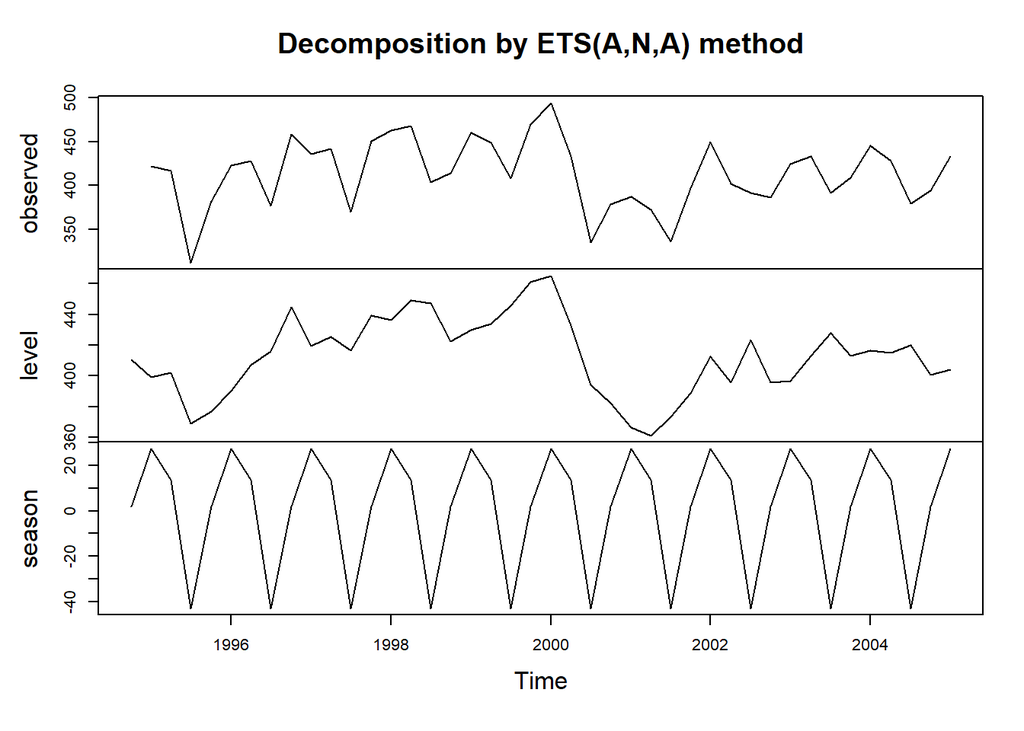

```r
plot(fit_ets_ukcars)
```

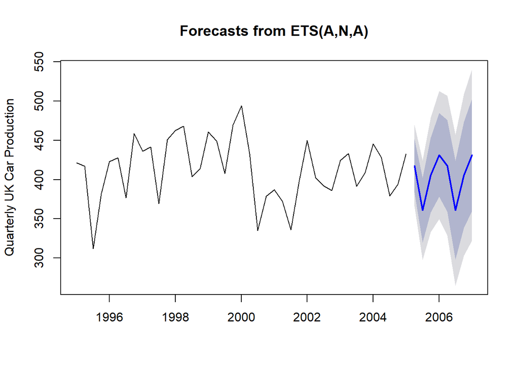

```r
plot(forecast(fit_ets_ukcars, h = 8), ylab = "Quarterly UK Car Production")
```

```r
fit_add$aic
```

```
## [1] 458.2162
```

```r
fit_mult$aic
```

```
## [1] 458.2156
```

The ANN and MNN methods both produced similar results, with the RMSE of the additive method showing only slightly lower. When I ran the third ETS, the model chose the ANA method with an RMSE of 24.374 as opposed to the ANN and MNN which both had an RMSE of nearly 39. When I ran the AIC for the ANN and MNN, their values were nearly identical as well.

6. Compare the forecasts from the above approaches. Which seems most reasonable? Why?

### Question 6

Look up the help file for the visitors data set (i.e. type ?visitors into R Studio console). The data set contains monthly short-term overseas visitors in Australia between May 1985 and April 2005.

```r
?visitors
```

1. Make a time plot of your data and describe the main features of the series. Forecast the next two years using Holt-Winters’ multiplicative method. Why is multiplicative seasonality necessary here?

Time plot & overview:

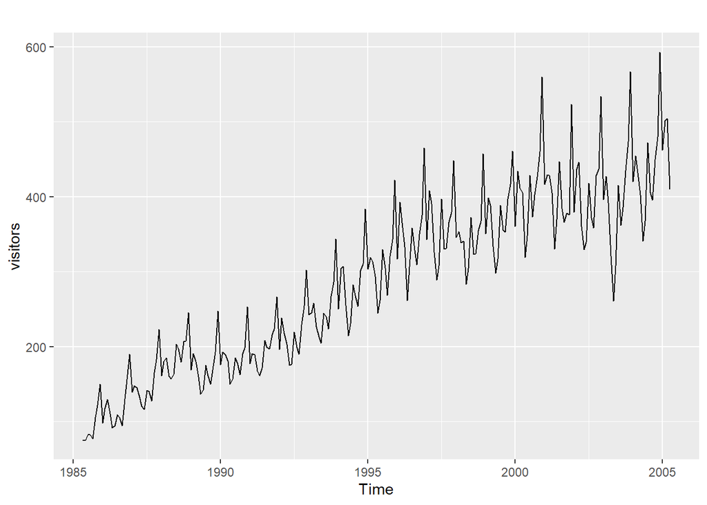

```r
autoplot(visitors)
```

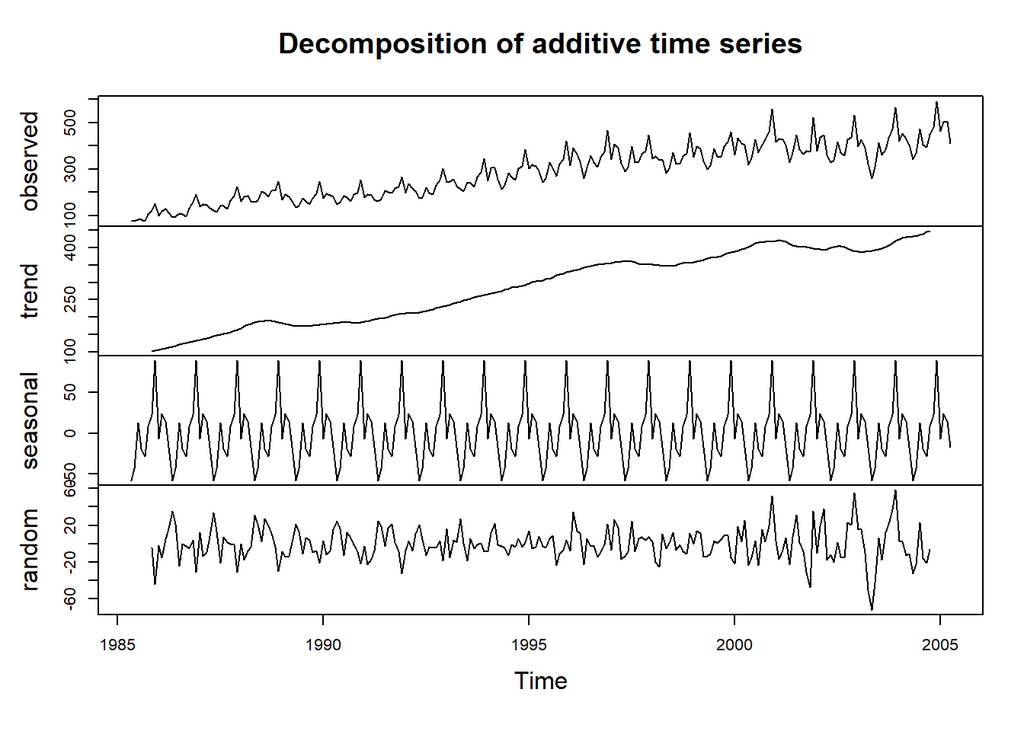

```r
plot(decompose(visitors))
```

Multiplicative decomposition since there is trend:

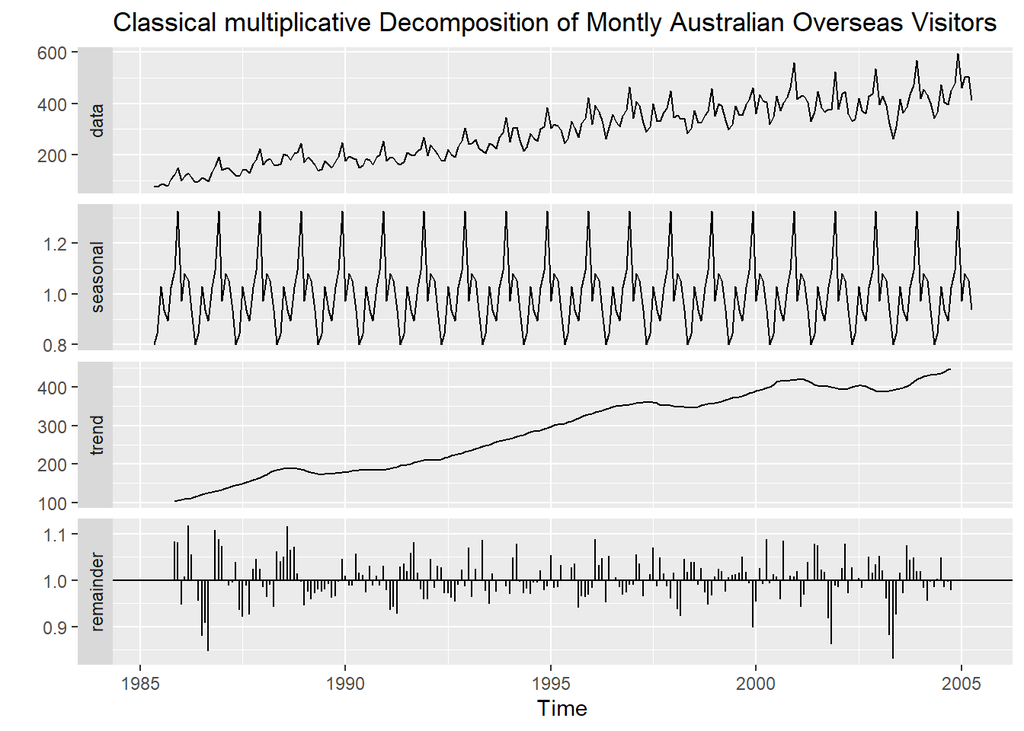

```r
visitors %>% decompose(type="multiplicative") %>%
  autoplot() + xlab("Time") +
  ggtitle("Classical multiplicative Decomposition of Montly Australian Overseas Visitors")
```

Travel seems to have been increasing steadily from 1985 until 2005, with peak visiting season being around the end of the year and dropping dramatically each January. Further decomposition confirms that there is upward trend and seasonality, and that there is little remainder data left over.

Holt-Winters’ multiplicative method:

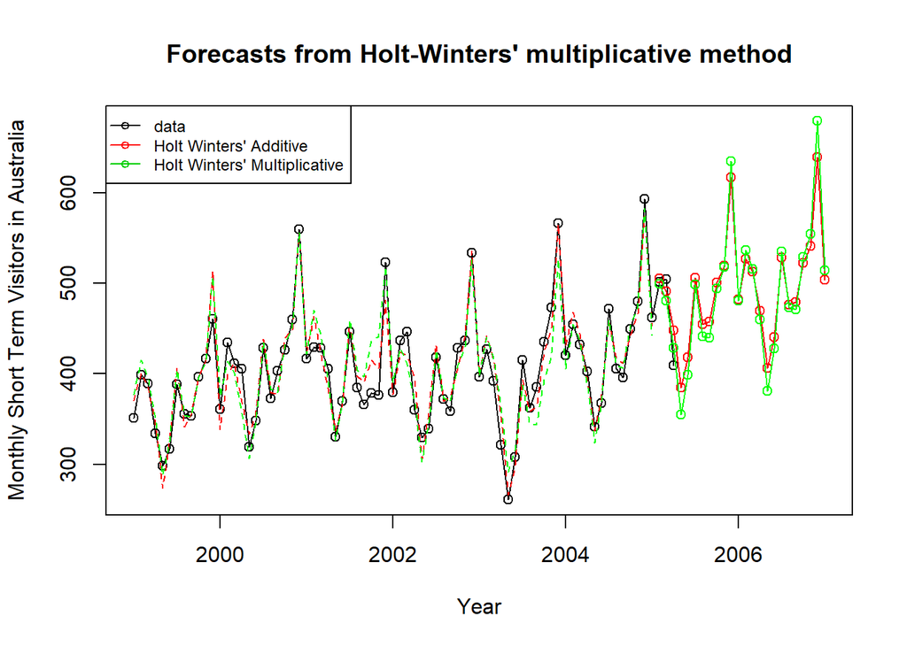

```r
aussie_window <- window(visitors, start=1999, end=2005) # less clutter
fit1hw <- hw(aussie_window,seasonal="additive")
fit2hw <- hw(aussie_window,seasonal="multiplicative")

test.aussie <- window(visitors, start=2005)
plot(fit2hw,ylab="Monthly Short Term Visitors in Australia",
     PI=FALSE, type="o", fcol="white", xlab="Year")
lines(test.aussie, col = "black", type = "o")
lines(fitted(fit1hw), col="red", lty=2)
lines(fitted(fit2hw), col="green", lty=2)
lines(fit1hw$mean, type="o", col="red")
lines(fit2hw$mean, type="o", col="green")
legend("topleft",lty=1, cex = 0.75, pch=1, col=1:3,
  c("data","Holt Winters' Additive","Holt Winters' Multiplicative"))
```

Multiplicative seasonality would be the preferred method because there is clear upward trend in the data. When ran alongside the additive forecast, we can see that the multiplicative forecast accounts for slightly more kurtosis and follows the nature of the past data more closely.

2. Experiment with making the trend exponential and/or damped, investigating at least two alternatives. Compare the RMSE of the one-step forecasts from the various methods. Which do you prefer? Why?

Exponential:

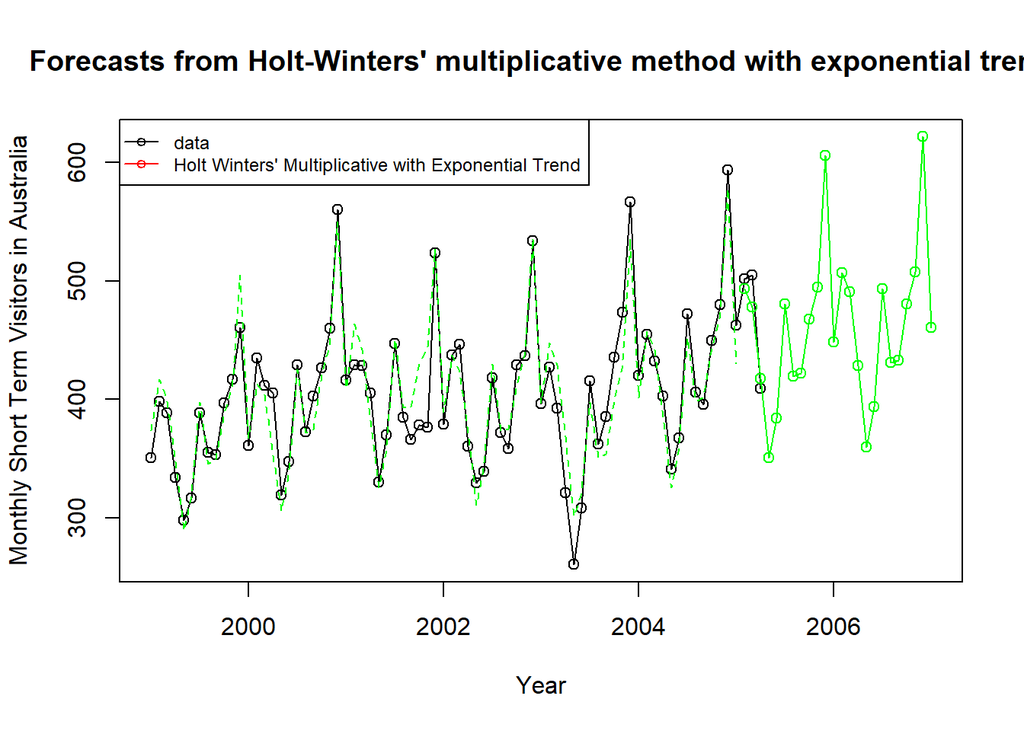

```r
fit2hw_expo <- hw(aussie_window,seasonal="multiplicative", exponential = TRUE)

test.aussie <- window(visitors, start=2005)
plot(fit2hw_expo,ylab="Monthly Short Term Visitors in Australia",
     PI=FALSE, type="o", fcol="white", xlab="Year")
lines(test.aussie, col = "black", type = "o")
lines(fitted(fit2hw_expo), col="green", lty=2)
lines(fit2hw_expo$mean, type="o", col="green")
legend("topleft",lty=1, cex = 0.75, pch=1, col=1:3,
  c("data","Holt Winters' Multiplicative with Exponential Trend"))
```

```r
summary(fit2hw_expo)
```

```
##
## Forecast method: Holt-Winters' multiplicative method with exponential trend
##
## Model Information:
## Holt-Winters' multiplicative method with exponential trend
##
## Call:
##  hw(y = aussie_window, seasonal = "multiplicative", exponential = TRUE)
##
##   Smoothing parameters:
##     alpha = 0.2008
##     beta  = 0.0018
##     gamma = 1e-04
##
##   Initial states:
##     l = 383.0243
##     b = 1.0019
##     s = 1.3173 1.0786 1.0226 0.9245 0.9214 1.0569
##            0.8466 0.7748 0.925 1.0604 1.0978 0.9742
##
##   sigma:  0.0616
##
##      AIC     AICc      BIC
## 796.7255 807.8528 835.6633
##
## Error measures:
##                    ME     RMSE      MAE         MPE    MAPE      MASE
## Training set 0.711291 21.76491 16.49892 -0.07030402 4.19331 0.5098968
##                  ACF1
## Training set 0.523541
##
## Forecasts:
##          Point Forecast    Lo 80    Hi 80    Lo 95    Hi 95
## Feb 2005       493.5468 454.4863 532.4015 434.3624 551.7186
## Mar 2005       477.8027 440.2130 516.6303 418.4179 538.1930
## Apr 2005       417.6806 384.3765 451.8029 365.8697 472.3946
## May 2005       350.6283 320.7956 380.0849 304.3478 396.2703
## Jun 2005       383.9526 350.6462 417.4268 333.5309 434.8084
## Jul 2005       480.3800 439.1690 521.0818 417.4044 543.6972
## Aug 2005       419.7196 382.6071 458.2149 365.9041 477.9389
## Sep 2005       422.0683 384.4306 460.0394 365.6386 480.7906
## Oct 2005       467.8360 424.5543 510.9052 403.2816 534.9244
## Nov 2005       494.5320 448.4662 540.7147 426.4809 565.2609
## Dec 2005       605.2856 548.2475 662.6285 520.3483 696.4523
## Jan 2006       448.6458 405.4989 491.3760 383.9894 518.2147
## Feb 2006       506.6288 456.4260 556.4578 434.4658 583.8867
## Mar 2006       490.4674 441.0521 539.9773 418.8548 569.9856
## Apr 2006       428.7517 386.2747 472.5778 364.5174 497.4689
## May 2006       359.9222 323.8554 397.2913 305.3602 417.4755
## Jun 2006       394.1298 352.3960 435.3200 331.3270 456.7547
## Jul 2006       493.1131 440.1812 545.9413 414.4902 574.8896
## Aug 2006       430.8448 385.5113 477.2832 364.0329 502.7781
## Sep 2006       433.2557 385.7910 480.0675 363.7226 507.2892
## Oct 2006       480.2366 427.4809 534.3869 402.8954 563.7822
## Nov 2006       507.6402 451.7982 565.1766 423.2539 597.0422
## Dec 2006       621.3294 552.6330 694.7110 521.5194 733.0194
## Jan 2007       460.5378 408.5339 514.3742 382.3965 544.9100
```

Damped:

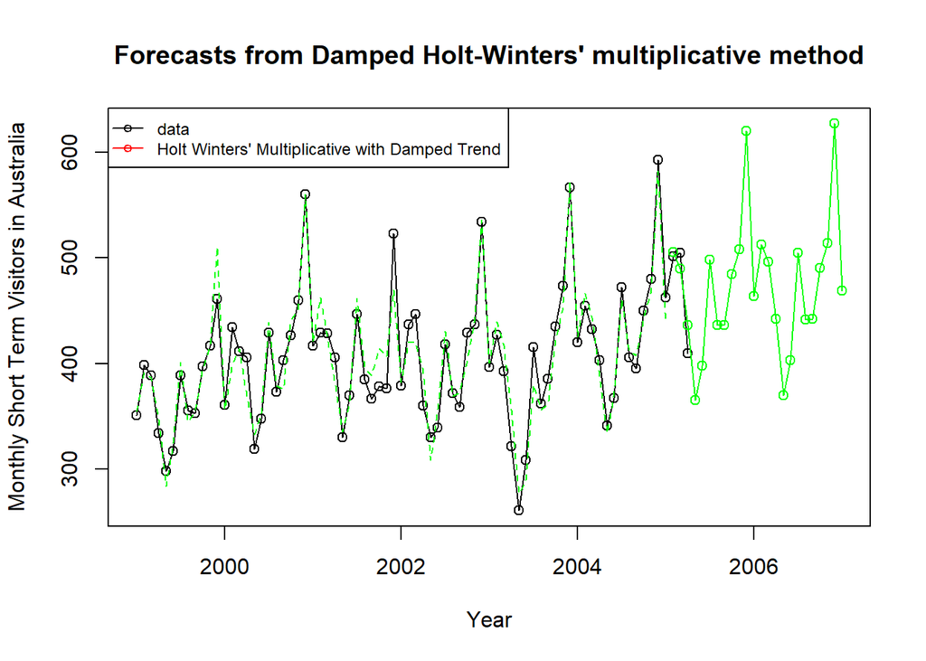

```r
fit2hw_damp <- hw(aussie_window,seasonal="multiplicative", exponential = FALSE, damped=TRUE)

test.aussie <- window(visitors, start=2005)
plot(fit2hw_damp,ylab="Monthly Short Term Visitors in Australia",
     PI=FALSE, type="o", fcol="white", xlab="Year")
lines(test.aussie, col = "black", type = "o")
lines(fitted(fit2hw_damp), col="green", lty=2)
lines(fit2hw_damp$mean, type="o", col="green")
legend("topleft",lty=1, cex = 0.75, pch=1, col=1:3,
  c("data","Holt Winters' Multiplicative with Damped Trend"))
```

```r
summary(fit2hw_damp)
```

```
##
## Forecast method: Damped Holt-Winters' multiplicative method
##
## Model Information:
## Damped Holt-Winters' multiplicative method
##
## Call:
##  hw(y = aussie_window, seasonal = "multiplicative", damped = TRUE,
##
##  Call:
##      exponential = FALSE)
##
##   Smoothing parameters:
##     alpha = 0.7458
##     beta  = 1e-04
##     gamma = 1e-04
##     phi   = 0.9797
##
##   Initial states:
##     l = 359.5174
##     b = 2.7667
##     s = 1.3121 1.0764 1.0283 0.927 0.9272 1.0608
##            0.8482 0.7789 0.9319 1.0469 1.0821 0.9803
##
##   sigma:  0.0527
##
##      AIC     AICc      BIC
## 774.9389 787.6055 816.1671
##
## Error measures:
##                      ME     RMSE      MAE       MPE     MAPE      MASE
## Training set 0.05204897 18.60731 14.42044 -0.135799 3.624063 0.4456617
##                    ACF1
## Training set 0.01080089
##
## Forecasts:
##          Point Forecast    Lo 80    Hi 80    Lo 95    Hi 95
## Feb 2005       505.3195 471.1730 539.4661 453.0969 557.5422
## Mar 2005       489.5208 448.2524 530.7892 426.4062 552.6354
## Apr 2005       436.3124 393.4600 479.1648 370.7753 501.8495
## May 2005       365.1088 324.8081 405.4096 303.4742 426.7435
## Jun 2005       398.0754 349.7784 446.3725 324.2114 471.9394
## Jul 2005       498.4903 433.0086 563.9719 398.3448 598.6357
## Aug 2005       436.1901 374.8283 497.5520 342.3453 530.0350
## Sep 2005       436.6239 371.3869 501.8608 336.8526 536.3951
## Oct 2005       484.8579 408.4136 561.3021 367.9465 601.7693
## Nov 2005       508.1146 424.0201 592.2092 379.5031 636.7262
## Dec 2005       620.0359 512.7769 727.2949 455.9974 784.0744
## Jan 2006       463.7301 380.1827 547.2774 335.9555 591.5047
## Feb 2006       512.4345 416.5748 608.2942 365.8298 659.0392
## Mar 2006       496.2648 400.1261 592.4036 349.2333 643.2964
## Apr 2006       442.1941 353.6832 530.7050 306.8283 577.5599
## May 2006       369.9249 293.5713 446.2786 253.1521 486.6978
## Jun 2006       403.2137 317.5458 488.8816 272.1960 534.2315
## Jul 2006       504.7868 394.5629 615.0107 336.2138 673.3597
## Aug 2006       441.5818 342.6232 540.5404 290.2376 592.9259
## Sep 2006       441.9055 340.3983 543.4126 286.6637 597.1473
## Oct 2006       490.5977 375.2206 605.9748 314.1436 667.0518
## Nov 2006       514.0015 390.3690 637.6340 324.9219 703.0810
## Dec 2006       627.0663 472.9523 781.1803 391.3693 862.7634
## Jan 2007       468.8762 351.2328 586.5197 288.9560 648.7964
```

Between the two, I would choose the damped Holt-Winters model because it follows the trend more conservatively and has a lower RMSE. It also performs more closely to the actual data.

3. Now use the ets() function to select a model automatically. Does it choose the same model you did? How would you explain that?

```r
fit_ets_visitors <- ets(aussie_window)
summary(fit_ets_visitors)
```

```
## ETS(A,N,A)
##
## Call:
##  ets(y = aussie_window)
##
##   Smoothing parameters:
##     alpha = 0.7596
##     gamma = 1e-04
##
##   Initial states:
##     l = 394.9557
##     s = 128.783 31.6466 12.166 -27.4773 -28.5054 26.0836
##            -59.436 -87.7838 -28.4366 16.8643 29.7249 -13.6292
##
##   sigma:  21.0695
##
##      AIC     AICc      BIC
## 772.6430 781.0640 806.9998
##
## Training set error measures:
##                    ME    RMSE      MAE       MPE     MAPE      MASE
## Training set 1.391178 18.9417 14.99319 0.1900319 3.777083 0.4633623
##                      ACF1
## Training set -0.003599025
```

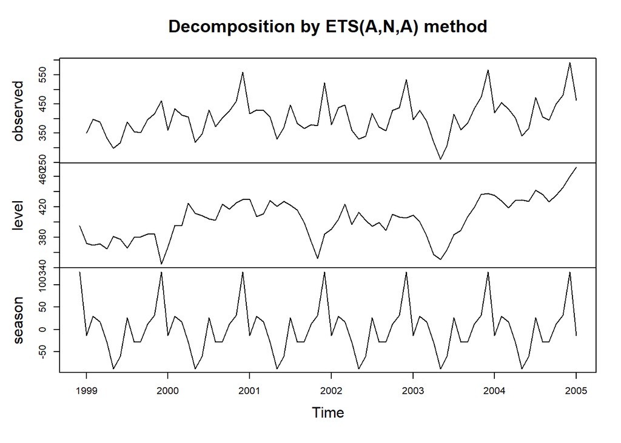

```r
plot(fit_ets_visitors)
```

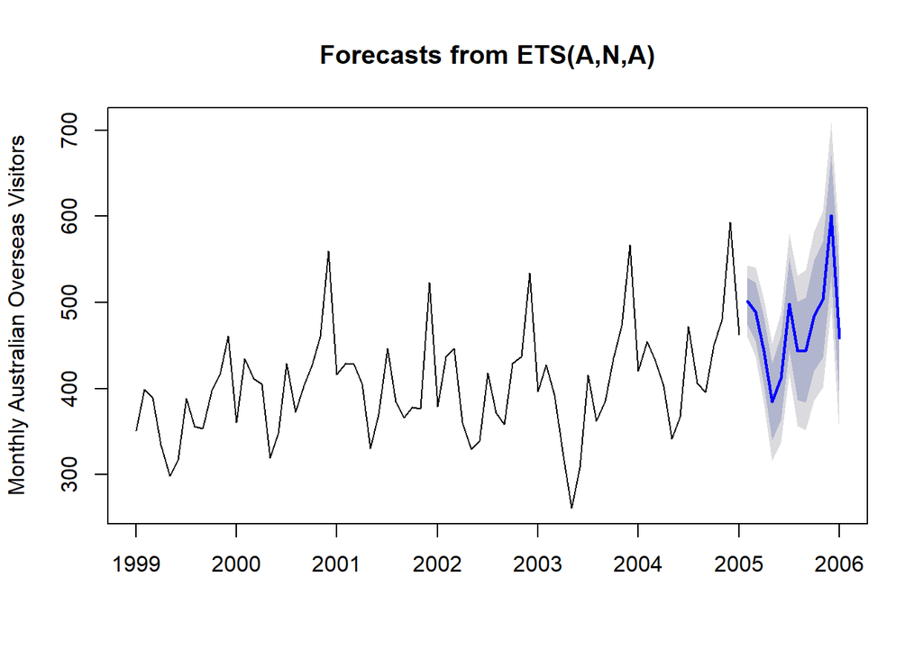

```r
plot(forecast(fit_ets_visitors, h = 12), ylab = "Monthly Australian Overseas Visitors")
```